# HIRN insulitis nCounter analysis

Heather Kates

10-09-2024

## Step 1. Load the nCounter data

Load the data downloaded from the GeoMX DSP Initial_Dataset.xlsx and received from Zeina.

First we will load the data as-is and perform no automatic QC trimming or normalization

```
##
## Loading count data......
## Averaging technical replicates.....
```

## Step 2. Quality Control

### Segment QC (housekeeping and background geomean)

The purpose of AOI-level QC is to identify AOIs with poor data that should be removed. We should look at both signal strength and background.

First, we will compute 2 metrics of AOI technical performance: • Housekeeper geomean: this captures signal strength. • IgG geomean: this captures background (negative controls), but in most experiments also reflects signal strength, as AOIs with more on-target signal also have more background.

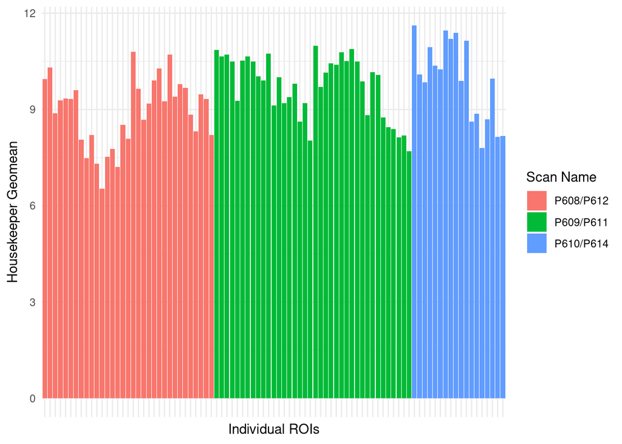

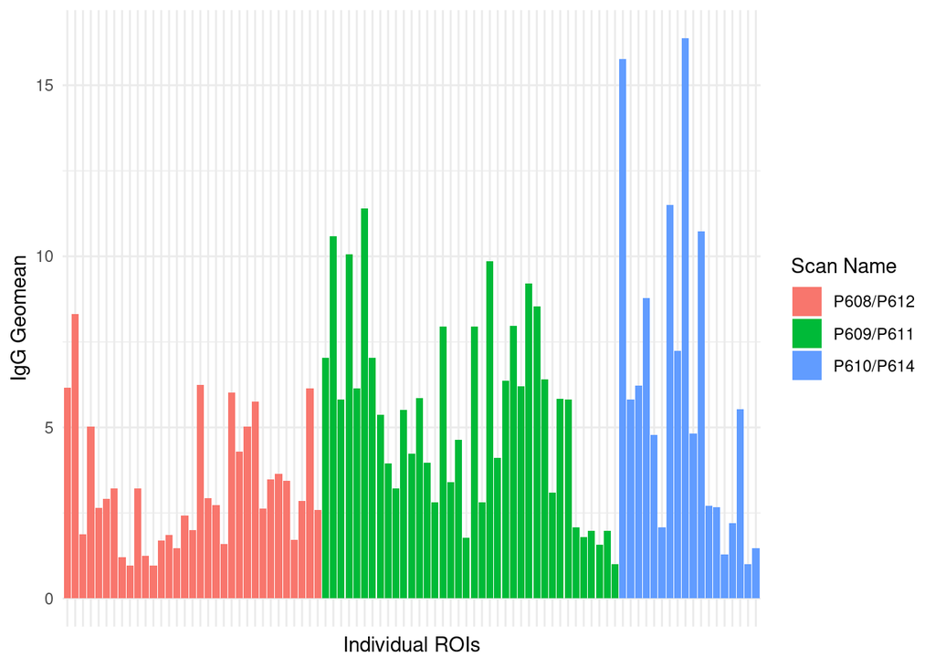

### Segment QC part II

Technical QC assessment includes FOV registration QC, Binding Density QC, Positive Control Normalization QC, Minimum nuclei count, Minimum surface area

```
##
## Loading count data......
## Averaging technical replicates.....
## Calculating positive scale factors......
## Checking endogenous genes against background threshold......
```

### Results of segment QC

| Custom_Segment_Name | FOV_QC_Flag | BindingDensity_QC_Flag | PCNorm_QC_Flag | NucleiCount_QC_Flag | SurfaceArea_QC_Flag |
| --- | --- | --- | --- | --- | --- |

### Probe QC

Probes that never rise above background should be interpreted carefully. The plot below shows a convenient way to identify poorly-performing probes.

Here we compute and plot the “signal-to-background” ratio per target, which is each AOI’s data divided by its IgG geomean.

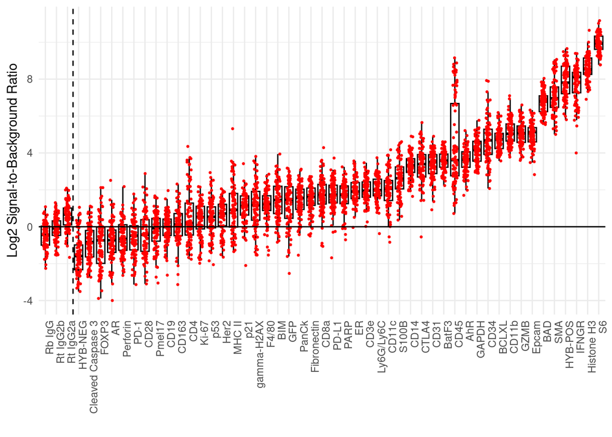

### Prune the dataset as needed

For now, we will leave all the probes in the dataset even though some have below background signal. We will make a list of these so that we can proceed with caution when evaluating results for these genes

## Step 3. Normalization

### Determine most appropriate normalization method

Options for normalization include housekeeping, negative control normalization, background correction, and scale to area or nuclei count.

It is not recommended to use multiple of these options, but instead to explore the data and choose one approach to normalize.

#### Explore IgG consistency (Negative control normalization)

Do the IgG’s have high enough counts to be used for normalization?

These IgGs measure background, which can be a normalization method to compare slides and/or cell populations

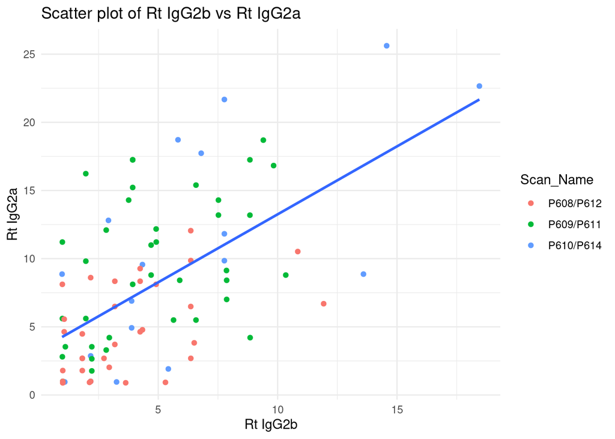

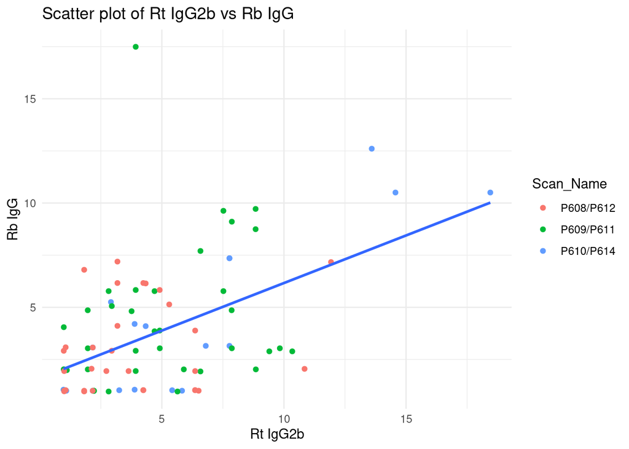

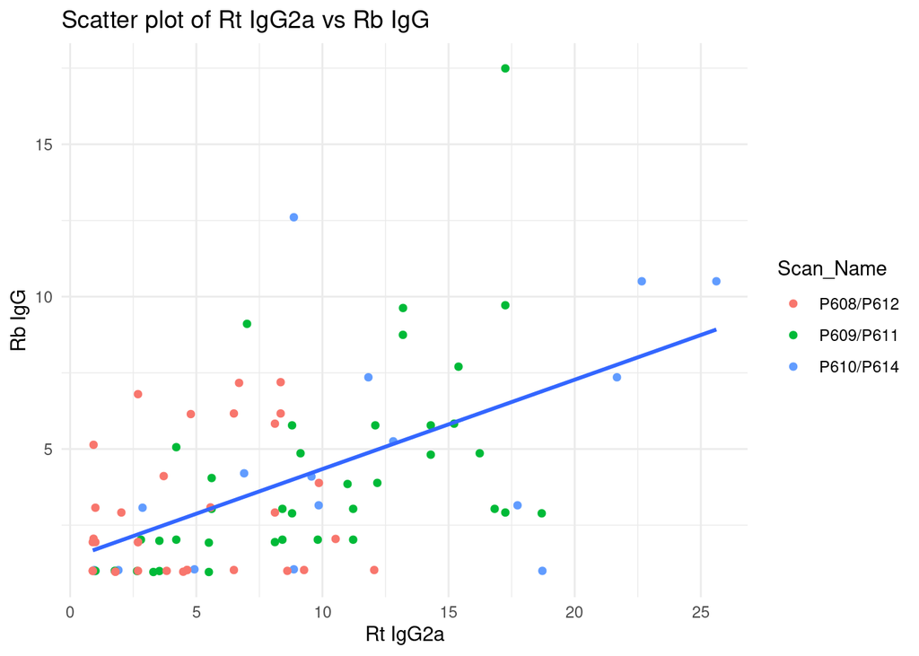

#### Explore Housekeeper consistency (Housekeeping normalization)

Assumes the housekeepers measure primarily signal strength

Housekeepers should be highly correlated (with consistent ratios between them)

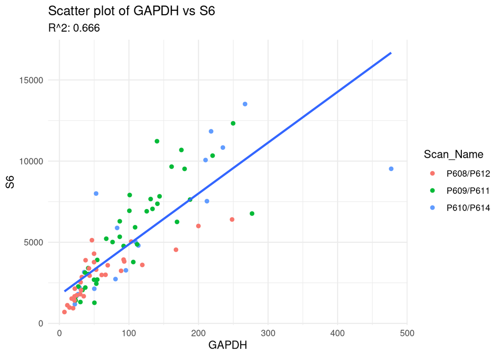

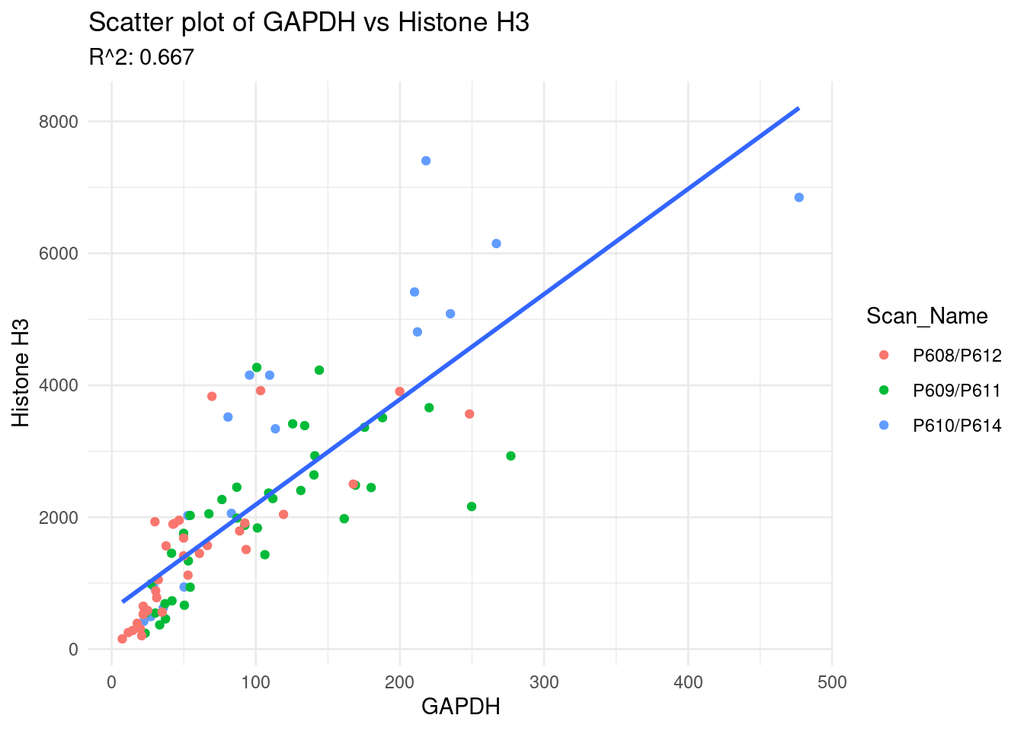

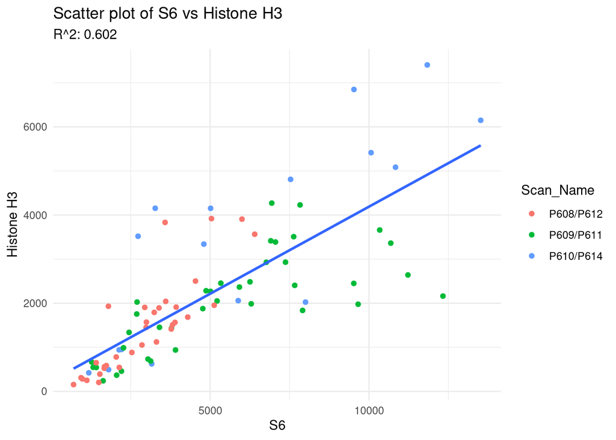

```
##                  Pair R_squared
## 1         GAPDH vs S6 0.6661341
## 2 GAPDH vs Histone H3 0.6671840
## 3    S6 vs Histone H3 0.6023689
```

#### Check for consistency between IgG’s, housekeepers, area, nuclei counts

Check how the different variables perform with respect to each other before normalization. This also let’s use assess whether scaling to area and nuclei counts is a viable approach.

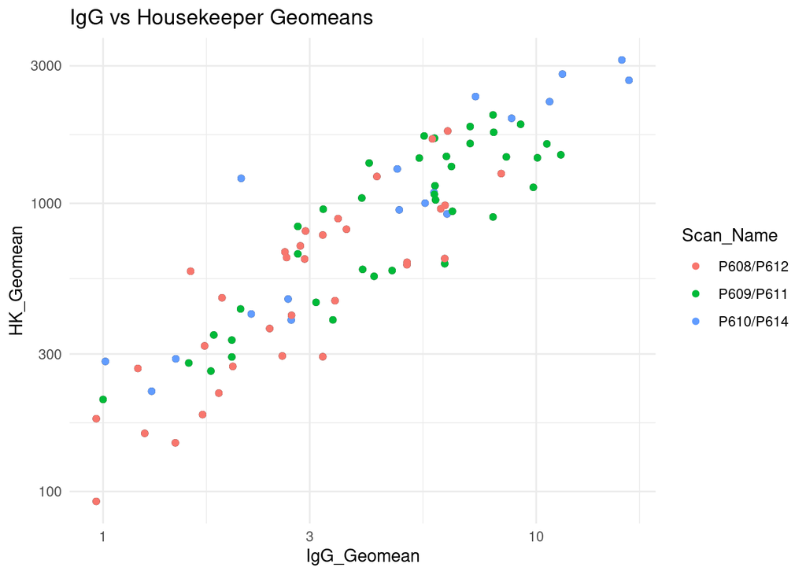

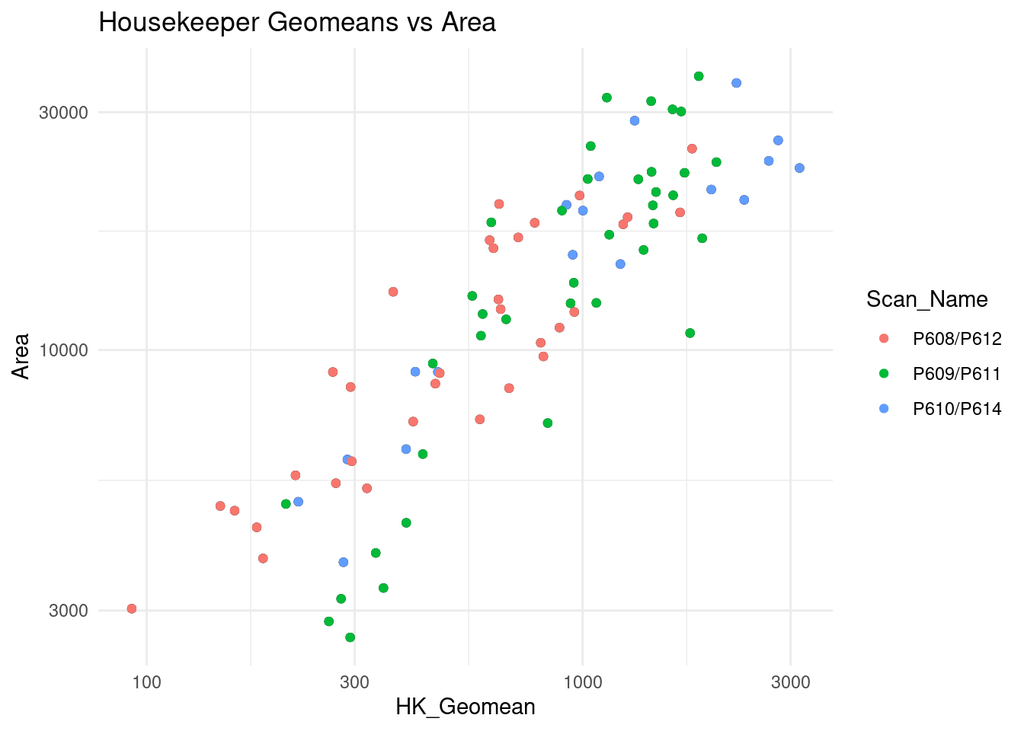

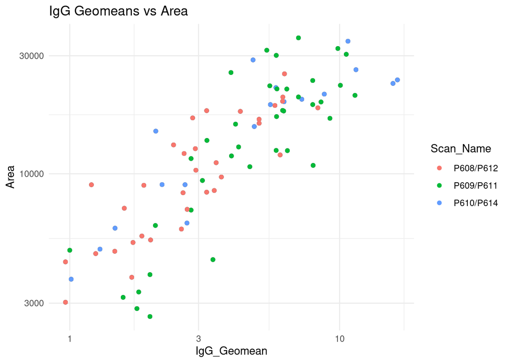

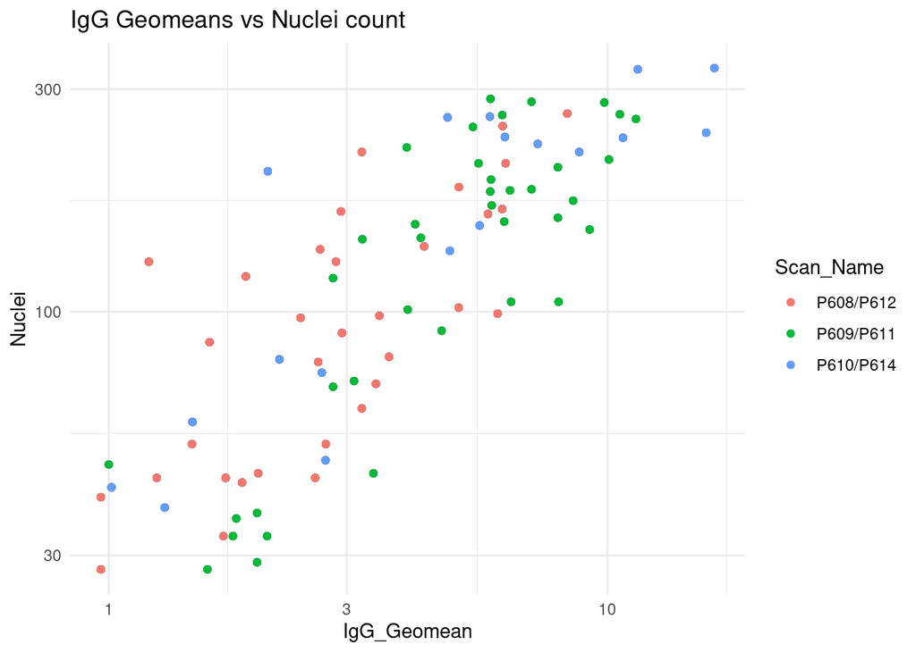

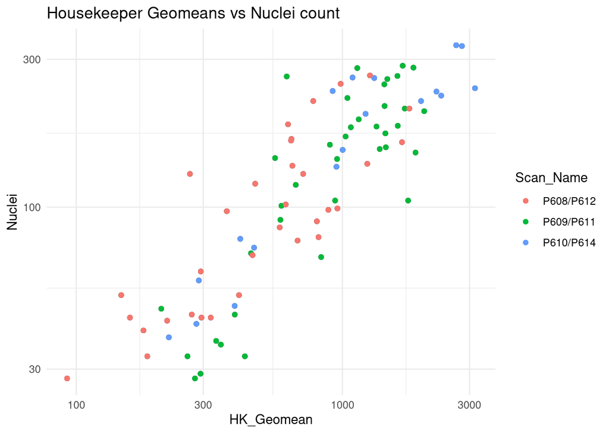

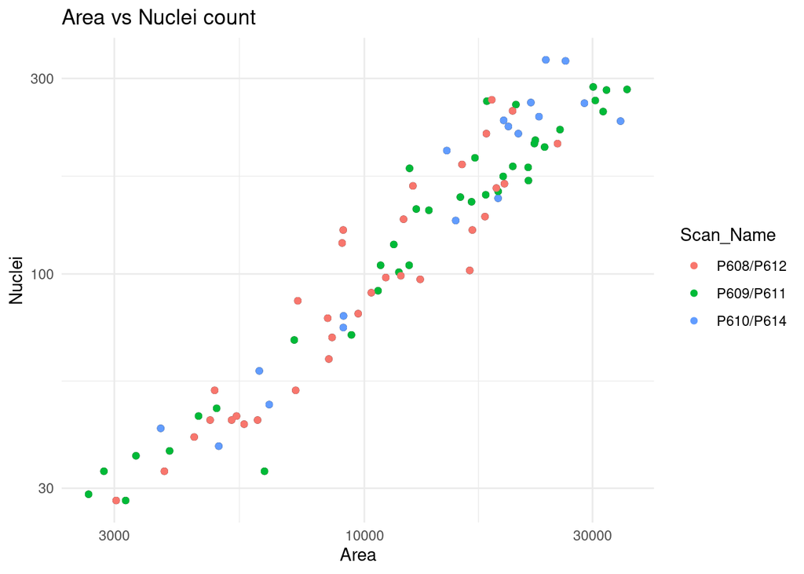

Based on these results, we can consider HK normalization and scaling to nuceli count or area.

#### Perform Normalization

```r
#Process the filtered data with housekeeping normalization, bgType = "none" prevents the low signal probes from being removed. Background subtraction is still performed.

HKnorm_data <- processNanostringData(nsFiles = "/blue/timgarrett/hkates/Campbell-Thompson/HIRN/results/filtered_counts.csv",
                             sampleTab = "/blue/timgarrett/hkates/Campbell-Thompson/HIRN/results/filtered_sample_data.csv",
                             idCol = "Custom_Segment_Name",
                             groupCol = "Segment_Tags",
                             bgType="none",
                             normalization = "nSolver",
                             bgSubtract = TRUE,
                             housekeeping = c("GAPDH","Histone H3","S6"))
```

```
##
## Loading count data......
## Averaging technical replicates.....
## Calculating positive scale factors......
## Checking endogenous genes against background threshold......
## Conducting housekeeping normalization......
```

## Step 4. Visualizations

### View metadata

Distribution of Groups

| Var1 | Freq |
| --- | --- |
| Islets_HET_non_Inflamed | 20 |
| Islets_KO_Inflamed | 29 |
| Islets_KO_Mild_inflammation | 5 |
| Islets_KO_non_Inflamed | 35 |

### PCA plot of ROIs colored by Scan_Name to assess batch effects

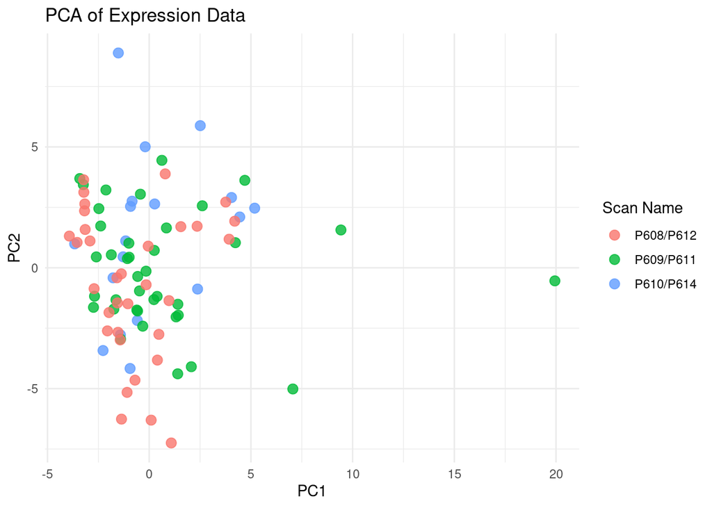

### PCA plot of ROIs colored by variable of interest

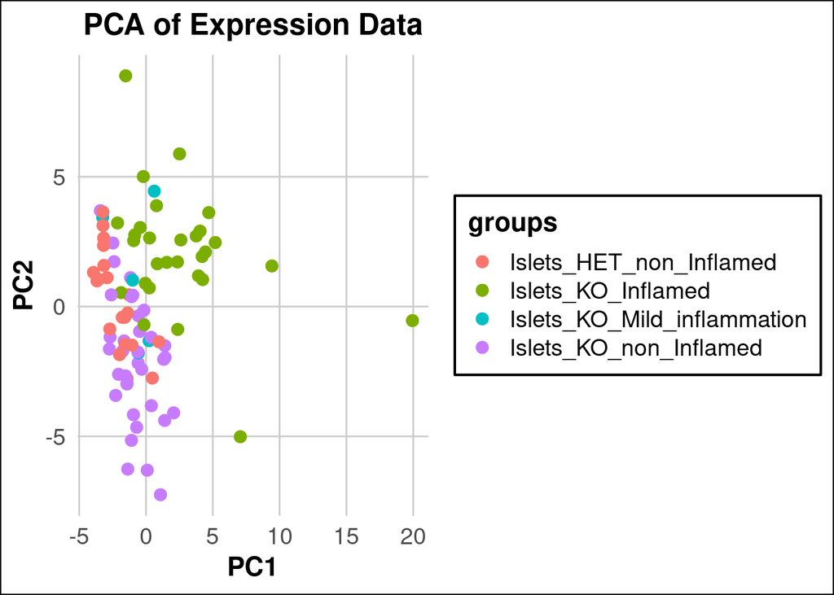

```
##
## Loading count data......
## Averaging technical replicates.....
## Calculating positive scale factors......
## Checking endogenous genes against background threshold......
## Conducting housekeeping normalization......
```

### Heatmap of all protein expression for the normalized segments

[figure not shown]

## Step 6. Differential Expression Analysis

Differential expression of proteins between “Segment_Tags” groups was determined by pairwise t tests using the R function pairwise.t.test. Global p-value correction to control the error rate across all the tests performed on the dataset was performed using Benjamini-Hochberg (BH) correction.